# Ee Sala Cup Namde?

### A statistical exploration of the Indian Premier League by Rishi Papani

## 0. Introduction and Setup

IPL or the Indian Premier League is an Indian mens cricket league and is the most popular cricket league in the world in terms of attendance, and in India in terms of viewership. The series consists of T20 (20 over matches) played between 10 teams from across India. As a refresher, cricket is batting sport where a ball is bowlled towards a batsman who then has to to hit it. The aim of the bowler (person throwing the ball) is to knock over the wicket (wooden rods standing behind the batsman), this scores a wicket which scores out the current batsman. The batsman's objective is to hit the ball with the bat as far as possible before then running back and forth from the wicket mound and the pitcher's mound - at which point the fielding team attempts to strike either him or either mound with the ball also scoring him out. Each time a batsman makes a successive run to either mound they score a point, additionally if they hit the ball far enough they are automatically awarded either 4 or 6 points depending on the distance the ball travels. Lastly, when a team is batting they may only have up to 10 wickets (players scored out) before their turn batting is over, at which point they switch positions with the fielding team. Each game consists of one team batting and then another, each either until they get 10 wickets or they exhaust their maximum allowed balls of 120 (each ball is a pitch essentially from the opposing team's bowler).

One particularly well known team in the IPL is RCB (Royal Challengers Bangalore), who despite having some of the most passionate fans in the league are yet to score a single IPL series win (this is essentially to win the tournament). To make matters even more bizarre, they also have some of the best batsmen in the league (in terms of ability to score runs) as well as in the world (i.e. Virat Kohli is an RCB player who is also the captain of India's national team, and recognized internationally as one of the best batsmen of all time). A common reason that people provide for RCB's predicament is that when players get auctioned on, RCB tends to go for a less balanced team. This means a few players who stand out in the cricket world, along with many players who are well below statistical average in terms of match outcomes. The reasoning goes that as such, RCB is excessively dependant on a few players whose single failures in a match can cause the whole team to lose (i.e. they get out first). Essentially, that although these star players are very good individually, they're not good enough to carry the entire performance of the team.

The purpose of this tutorial is to test our hypothesis is that teams excessively dependant on fewer players tend to have poorer performance thorughout the series as compared to their more balance counterparts. For the purpose of this tutorial, we measure this dependence with regards to how even a team is in terms of player ability - a metric whose calculation we will describe at a later point. Additionally, we also aim to see if RCB is less balanced as a whole when compared to other teams in the league.

##### 1. Data Wrangling

First we'll be reading our data (obtained [here]https://www.kaggle.com/datasets/patrickb1912/ipl-complete-dataset-20082020?select=IPL+Matches+2008-2020.csv)) and organizing it into an easily accessible data structure. Our dataset has two csv files, one for broader data regarding every IPL Match between 2008-2020 and another for specific data on each individual ball for each individual match in this period. Firstly, we'll only be considering matches within the past 5 seasons, this is because IPL team strategies can vary greatly by season so a large aggregate would dull many significant statistical trends. This means that elements of a team that would work at one point wouldn't work at other points (i.e. it may have been better in the past to be more balanced, as compared to now).

```python
#importing libraries for our entire notebook
import seaborn as sns #for plots
import matplotlib.pyplot as plt
import matplotlib as mpl
import pandas as pd #For organizing, holding, and accessing data
from sklearn.linear_model import LinearRegression #to build a prediction model

#Reading Match Data
Matches = pd.read_csv("IPL Matches 2008-2020.csv")
Balls = pd.read_csv("IPL Ball-by-Ball 2008-2020.csv")

#Displaying
Matches.head()
```

|  | id | city | date | player_of_match | venue | neutral_venue | team1 | team2 | toss_winner | toss_decision | winner | result | result_margin | eliminator | method | umpire1 | umpire2 |
| --- | --- | --- | --- | --- | --- | --- | --- | --- | --- | --- | --- | --- | --- | --- | --- | --- | --- |
| 0 | 335982 | Bangalore | 2008-04-18 | BB McCullum | M Chinnaswamy Stadium | 0 | Royal Challengers Bangalore | Kolkata Knight Riders | Royal Challengers Bangalore | field | Kolkata Knight Riders | runs | 140.0 | N | NaN | Asad Rauf | RE Koertzen |
| 1 | 335983 | Chandigarh | 2008-04-19 | MEK Hussey | Punjab Cricket Association Stadium, Mohali | 0 | Kings XI Punjab | Chennai Super Kings | Chennai Super Kings | bat | Chennai Super Kings | runs | 33.0 | N | NaN | MR Benson | SL Shastri |
| 2 | 335984 | Delhi | 2008-04-19 | MF Maharoof | Feroz Shah Kotla | 0 | Delhi Daredevils | Rajasthan Royals | Rajasthan Royals | bat | Delhi Daredevils | wickets | 9.0 | N | NaN | Aleem Dar | GA Pratapkumar |
| 3 | 335985 | Mumbai | 2008-04-20 | MV Boucher | Wankhede Stadium | 0 | Mumbai Indians | Royal Challengers Bangalore | Mumbai Indians | bat | Royal Challengers Bangalore | wickets | 5.0 | N | NaN | SJ Davis | DJ Harper |
| 4 | 335986 | Kolkata | 2008-04-20 | DJ Hussey | Eden Gardens | 0 | Kolkata Knight Riders | Deccan Chargers | Deccan Chargers | bat | Kolkata Knight Riders | wickets | 5.0 | N | NaN | BF Bowden | K Hariharan |

```python
#Filtering by Season
Matches = Matches[Matches["date"] > '2016-01-01']

Matches.head()
```

|  | id | city | date | player_of_match | venue | neutral_venue | team1 | team2 | toss_winner | toss_decision | winner | result | result_margin | eliminator | method | umpire1 | umpire2 |
| --- | --- | --- | --- | --- | --- | --- | --- | --- | --- | --- | --- | --- | --- | --- | --- | --- | --- |
| 517 | 980901 | Mumbai | 2016-04-09 | AM Rahane | Wankhede Stadium | 0 | Mumbai Indians | Rising Pune Supergiants | Mumbai Indians | bat | Rising Pune Supergiants | wickets | 9.0 | N | NaN | HDPK Dharmasena | CK Nandan |
| 518 | 980903 | Kolkata | 2016-04-10 | AD Russell | Eden Gardens | 0 | Kolkata Knight Riders | Delhi Daredevils | Kolkata Knight Riders | field | Kolkata Knight Riders | wickets | 9.0 | N | NaN | S Ravi | C Shamshuddin |
| 519 | 980905 | Chandigarh | 2016-04-11 | AJ Finch | Punjab Cricket Association IS Bindra Stadium, ... | 0 | Kings XI Punjab | Gujarat Lions | Gujarat Lions | field | Gujarat Lions | wickets | 5.0 | N | NaN | AK Chaudhary | VA Kulkarni |
| 520 | 980907 | Bangalore | 2016-04-12 | AB de Villiers | M Chinnaswamy Stadium | 0 | Royal Challengers Bangalore | Sunrisers Hyderabad | Sunrisers Hyderabad | field | Royal Challengers Bangalore | runs | 45.0 | N | NaN | HDPK Dharmasena | VK Sharma |
| 521 | 980909 | Kolkata | 2016-04-13 | RG Sharma | Eden Gardens | 0 | Kolkata Knight Riders | Mumbai Indians | Mumbai Indians | field | Mumbai Indians | wickets | 6.0 | N | NaN | Nitin Menon | S Ravi |

A quick look at the data can show that each ball bowled in each game shares the same id as the game as a whole, as such to filter the relevant balls we need only filter ids. Furthermore, the id of a game increases as time goes on so we can just take the minimum or first id from above and proceed.

```python
Balls = Balls[Balls["id"] >= 980901]

Balls.head()
```

|  | id | inning | over | ball | batsman | non_striker | bowler | batsman_runs | extra_runs | total_runs | non_boundary | is_wicket | dismissal_kind | player_dismissed | fielder | extras_type | batting_team | bowling_team |
| --- | --- | --- | --- | --- | --- | --- | --- | --- | --- | --- | --- | --- | --- | --- | --- | --- | --- | --- |
| 122434 | 980901 | 1 | 1 | 1 | RG Sharma | LMP Simmons | I Sharma | 0 | 0 | 0 | 0 | 1 | lbw | RG Sharma | NaN | NaN | Mumbai Indians | Rising Pune Supergiants |
| 122435 | 980901 | 1 | 0 | 4 | RG Sharma | LMP Simmons | RP Singh | 4 | 0 | 4 | 0 | 0 | NaN | NaN | NaN | NaN | Mumbai Indians | Rising Pune Supergiants |
| 122436 | 980901 | 1 | 0 | 5 | RG Sharma | LMP Simmons | RP Singh | 1 | 0 | 1 | 0 | 0 | NaN | NaN | NaN | NaN | Mumbai Indians | Rising Pune Supergiants |
| 122437 | 980901 | 1 | 0 | 6 | LMP Simmons | RG Sharma | RP Singh | 0 | 0 | 0 | 0 | 0 | NaN | NaN | NaN | NaN | Mumbai Indians | Rising Pune Supergiants |
| 122438 | 980901 | 1 | 1 | 5 | HH Pandya | LMP Simmons | I Sharma | 0 | 0 | 0 | 0 | 0 | NaN | NaN | NaN | NaN | Mumbai Indians | Rising Pune Supergiants |

## 2. Computing Player Ability

Firstly, we'll be analyzing the per team, per game effects of being unbalanced. To measure balance we'll be taking the percentage contribution of the total runs in a game of each player. Here a more unbalanced and singularly dependant team would have less players taking a much larger share of the runs. To measure variation on this, essentially balance, we'll observe the distribution of this metric. We'll do this by calculating the standard deviation of each player's contribution to each game per team.

First we'll calculate individual contribution for batsmen with the above metric of contribution to runs.

```python
#Aggregating data by relevant metrics
PG = Balls.groupby(["id", "batting_team", "batsman"])

#Suming the total runs of each player in a game, as well as their balls
Player_Game = PG.agg(
        sum_runs = ('total_runs', 'sum'),
        sum_balls = ('ball', 'count')
    )

Player_Game['run_rate'] = Player_Game['sum_runs'] / Player_Game['sum_balls']

#Calculating the contribution of a player to a certain match's total runs
def perc_calc(row):
    return (row['sum_runs'] / Player_Game.loc[row.name[0], row.name[1]]["sum_runs"].sum())

Player_Game['run_percentage'] = Player_Game.apply(lambda row: perc_calc(row), axis=1)

#Viewing
Player_Game.head()
```

| id | batting_team | batsman | sum_runs | sum_balls | run_rate | run_percentage |
| --- | --- | --- | --- | --- | --- | --- |
| 980901 | Mumbai Indians | AT Rayudu | 23 | 28 | 0.821429 | 0.190083 |
|  |  | HH Pandya | 14 | 13 | 1.076923 | 0.115702 |
|  |  | Harbhajan Singh | 46 | 31 | 1.483871 | 0.380165 |
|  |  | JC Buttler | 0 | 2 | 0.000000 | 0.000000 |
|  |  | KA Pollard | 7 | 10 | 0.700000 | 0.057851 |

Next we'll be calculating the contribution of each bowler via contribution of wickets onto the opposing team. This is a harder metric to quantify as wickets are strategically much more complex and are limited every game. However, bowlers are known for their abilities to throw balls that give their team the best possible chances of scoring a wicket, be it by implicitly aiming to ball to fly in a direction or just knocking over the wooden wickets. Our method will be largely the same and parallel to the above.

```python
#Aggregating data by relevant metrics
PG = Balls.groupby(["id", "batting_team", "bowler"])

#Suming the total wickets of each bowler in a game, as well as their balls
Bowler_Game = PG.agg(
        sum_wickets = ('is_wicket', 'sum'),
        sum_balls = ('ball', 'count')
    )

Bowler_Game['wicket_rate'] = Bowler_Game['sum_wickets'] / Bowler_Game['sum_balls']

#Calculating the contribution of a bowler to a certain match's total wickets
def perc_calc(row):
    return (row['sum_wickets'] / Bowler_Game.loc[row.name[0], row.name[1]]["sum_wickets"].sum())

Bowler_Game['wicket_percentage'] = Bowler_Game.apply(lambda row: perc_calc(row), axis=1)

#Viewing
Bowler_Game.head()
```

| id | batting_team | bowler | sum_wickets | sum_balls | wicket_rate | wicket_percentage |
| --- | --- | --- | --- | --- | --- | --- |
| 980901 | Mumbai Indians | I Sharma | 2 | 28 | 0.071429 | 0.250 |
|  |  | M Ashwin | 1 | 24 | 0.041667 | 0.125 |
|  |  | MR Marsh | 2 | 25 | 0.080000 | 0.250 |
|  |  | R Ashwin | 1 | 6 | 0.166667 | 0.125 |
|  |  | R Bhatia | 1 | 24 | 0.041667 | 0.125 |

## 3. Observing a correlation between the balance of a team and victories

We'll now be analyzing any correlation between a team's particular balance and their chance of winning in a particular match. To measure balance we will be using the aforementioned metric of standard deviation of contribution. Firstly we'll be doing this for batsmen, and then plotting them against wins to observe any patterns.

```python
#Calculate scoring for a match
def run_calc(team, row):
    return Player_Game.loc[row['id'], row[team]]["sum_runs"].sum()

#Calculate standard deviation of contribution per team per match
def dev_calc(team, row):
    return Player_Game.loc[row['id'], row[team]]["run_percentage"].std()

#Creating a new column to make the winner of a match numerically representable
def winner(row):
    if row["t1_runs"] == row["t2_runs"]:
        return 0
    elif row["t1_runs"] > row["t2_runs"]:
        return 1
    else:
        return 2

#Applying the above functions to our Matches Dataframe to get appropriate columns
Matches["t1_runs"] = Matches.apply(lambda row: run_calc('team1', row), axis=1)
Matches["t2_runs"] = Matches.apply(lambda row: run_calc('team2', row), axis=1)

Matches["winning_team"] = Matches.apply(lambda row: winner(row), axis=1)

Matches["t1_run_dev"] = Matches.apply(lambda row: dev_calc('team1', row), axis=1)
Matches["t2_run_dev"] = Matches.apply(lambda row: dev_calc('team2', row), axis=1)

Matches["dev_ratio"] = Matches.apply(lambda row: dratio(row), axis=1)

Matches.head()
```

|  | id | city | date | player_of_match | venue | neutral_venue | team1 | team2 | toss_winner | toss_decision | ... | eliminator | method | umpire1 | umpire2 | t1_runs | t2_runs | winning_team | t1_run_dev | t2_run_dev | dev_ratio |
| --- | --- | --- | --- | --- | --- | --- | --- | --- | --- | --- | --- | --- | --- | --- | --- | --- | --- | --- | --- | --- | --- |
| 517 | 980901 | Mumbai | 2016-04-09 | AM Rahane | Wankhede Stadium | 0 | Mumbai Indians | Rising Pune Supergiants | Mumbai Indians | bat | ... | N | NaN | HDPK Dharmasena | CK Nandan | 121 | 126 | 2 | 0.113280 | 0.181848 | -0.068568 |
| 518 | 980903 | Kolkata | 2016-04-10 | AD Russell | Eden Gardens | 0 | Kolkata Knight Riders | Delhi Daredevils | Kolkata Knight Riders | field | ... | N | NaN | S Ravi | C Shamshuddin | 99 | 98 | 1 | 0.157459 | 0.058521 | 0.098938 |
| 519 | 980905 | Chandigarh | 2016-04-11 | AJ Finch | Punjab Cricket Association IS Bindra Stadium, ... | 0 | Kings XI Punjab | Gujarat Lions | Gujarat Lions | field | ... | N | NaN | AK Chaudhary | VA Kulkarni | 161 | 162 | 2 | 0.104180 | 0.165037 | -0.060856 |
| 520 | 980907 | Bangalore | 2016-04-12 | AB de Villiers | M Chinnaswamy Stadium | 0 | Royal Challengers Bangalore | Sunrisers Hyderabad | Sunrisers Hyderabad | field | ... | N | NaN | HDPK Dharmasena | VK Sharma | 227 | 182 | 1 | 0.154409 | 0.107500 | 0.046910 |
| 521 | 980909 | Kolkata | 2016-04-13 | RG Sharma | Eden Gardens | 0 | Kolkata Knight Riders | Mumbai Indians | Mumbai Indians | field | ... | N | NaN | Nitin Menon | S Ravi | 187 | 188 | 2 | 0.141340 | 0.158852 | -0.017512 |

5 rows × 23 columns

Now we can plot the standard deviation of one team against another along with who wins to see if there's a pattern. We'll be using color to denote the winner, with 0 being a tie, and have the team 1 standard deviation on the x axis, and the team 2 deviation on the y axis.

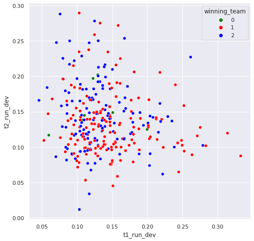

```python
sns.set(rc = {'figure.figsize':(8,8)})
splt1 = sns.scatterplot(data = Matches,
                        x = "t1_run_dev",
                        y = "t2_run_dev",
                        hue="winning_team",
                        palette=['green','red', 'blue'])
```

### Royal Challengers Bangalore's Balance

Lastly we'll be using a violin plot to visualize the distribution of RCB's balance across games. In particular we'll be vizualizing the distribution and occurrence of each standard devation per game per team to see how often a team has a certain balance.

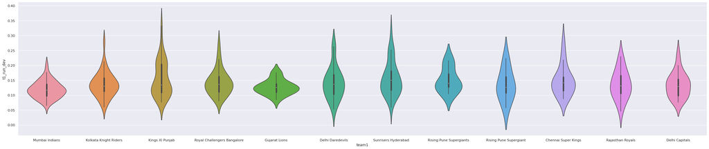

```python
sns.set(rc = {'figure.figsize':(40,8)})
sns.violinplot(data = Matches,
               x = "team1",
               y = "t1_run_dev")
```

#### An analysis of the above

From the above we can see the Royal Challengers Bangalore actually has a similar and in many ways more balanced performance as compared to other teams. In particular it has a less flat distribution curve than many other teams, and it also has an average and more that is at or below that of other teams, in fact some other teams here have massively skewed distributions. Essentially the fact that RCB has less average deviation of contribution means it is more balanced.

## 4. Conclusion

From the above two charts we can observe two things. Firstly, on our scatter plot, whenever a team has a significantly larger standard deviation of run contribution than the other, they are much more likely to win. Secondly, that Royal Challengers Bangalore doesn't have a significantly larger average standard distribution of run contribution as compared to other teams. In fact there are many other teams that sport a higher average standard deviation of run contribution per match, and also are more spread out on the higher end than RCB. In terms of our hypothesis, we were wrong, not only does better balance lead to worse outcomes per match but RCB is also not any more significantly unbalanced than other teams. Although this could just be a limitation or mirage of our methods, for the time being it looks like the common argument is just wrong by these means. And lastly, the title 'ee sala cup namde' is just a local team cheer meaning 'this time the cup is ours', but after trying to diagnose the problem here, it looks like we'll need some more statistical analysis before we can really say that.